# Ebola Cases in Guinea

# Background

Ebola virus disease (EVD), or simply Ebola, is a viral haemorrhagic fever of humans and other primates caused by ebolaviruses. Signs and symptoms typically start between two days and three weeks after contracting the virus with a fever, sore throat, muscular pain, and headaches. The disease has a high risk of death, killing 25% to 90% of those infected, with an average of about 50%.

An extremely dangerous virus, Ebola is transmitted from animal to human and from human to human through direct contact with or ingestion of bodily fluids from an infected individual. Once someone has been infected by the Ebola virus, they go through an incubation period where they show no symptoms and are not contagious; this period can last anywhere from 2 to 21 days. The symptoms of Ebola are often mistaken for those of other tropical diseases such as malaria or typhoid, making it very difficult to diagnose and control. Another important factor in the spread of Ebola are burial rituals, many of which require close contact with the deceased, whose body can still contain the virus and pass it on. Because of these factors, and the insufficient healthcare infrastructure in many West African communities, Ebola spread rampantly and wreaked havoc for many months

An epidemic of Ebola virus disease in Guinea from 2013 to 2016 represents the first ever outbreak of Ebola in a West African country.

The data I will be using is the number of confirmed Ebola cases in the last 21 days from 2014-8-29 through to the end of 2015 in Guinea.

# Data Exploration

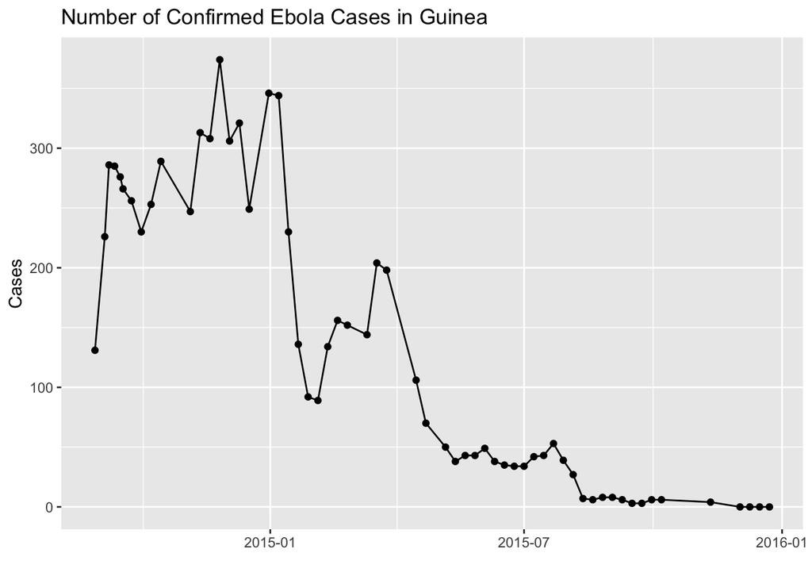

```r
ebola<-read.csv(file = "ebola.csv", header = T, stringsAsFactors = FALSE, colClasses = c(Date = "Date"))
#ebola<-subset(ebola, Country=='Guinea' )
ebola<-subset(ebola, Country=='Guinea'& Indicator=='Number of confirmed Ebola cases in the last 21 days' )
ebola<-ebola[order(ebola$Date),]
ggplot(data=ebola,aes(x=Date,y=value)) + geom_point() + geom_path() + labs(x = "", y = "Cases", title = "Number of Confirmed Ebola Cases in Guinea")
```

## Date transmission

To better manipulate the data, I transmit the date from yy-mm-dd to day type.

```r
ebola$day=unclass(as.Date(ebola$Date))-16310
```

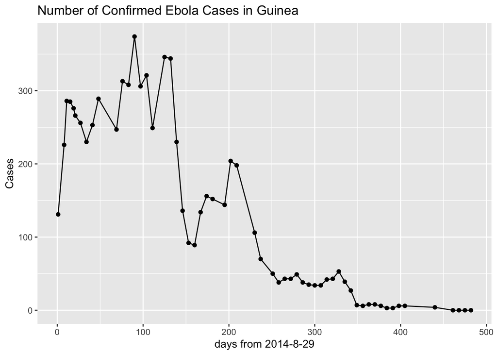

```r
ggplot(data=ebola,aes(x=day,y=value)) + geom_point() + geom_path() + labs(x = "days from 2014-8-29", y = "Cases", title = "Number of Confirmed Ebola Cases in Guinea")
```

```r
summary(ebola$value)
```

```
##    Min. 1st Qu.  Median    Mean 3rd Qu.    Max.
##     0.0    30.5    89.0   129.5   248.0   374.0
```

```r
ebola$Date[which.max(ebola$value)]
```

```
## [1] "2014-11-26"
```

From the plot above, confirmed case reaches its maximum 374 on 2014-11-26. Additionally, we see a effectively decreasing trend in the latter half part of the plot. That means the epidemic almostly ended by the end of 2015.

# ARMA Model Fitting

## Frequency domian analysis

```r
tp<-ebola$value
head(tp,20)
```

```
##  [1] 131 226 286 285 276 266 256 230 253 289 247 313 308 374 306 321 249
## [18] 346 344 230
```

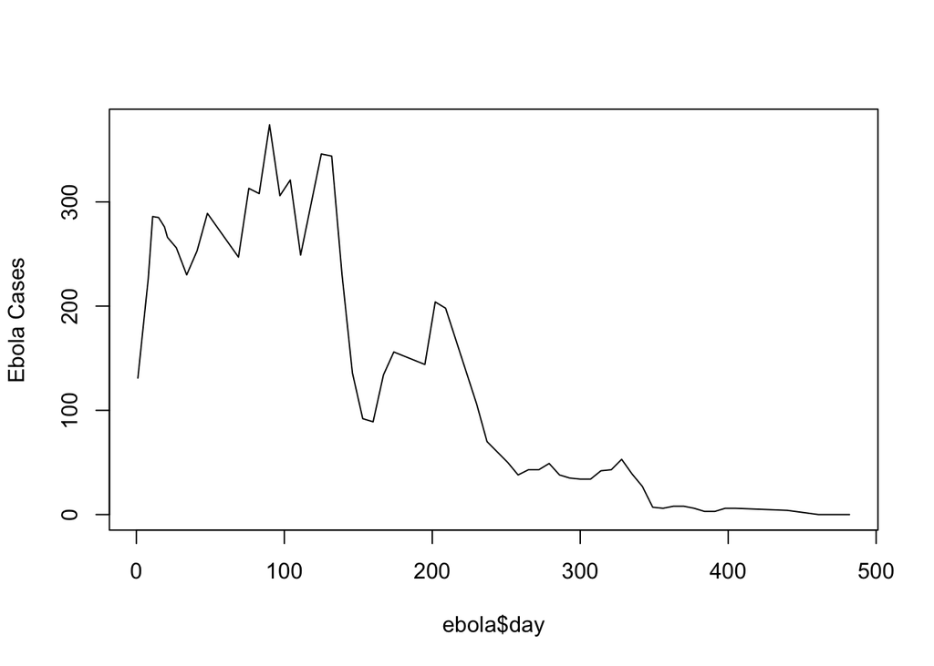

```r
tp[which(is.na(tp))]<-mean(tp,na.rm=TRUE)
plot(tp~ebola$day,type="l",ylab = "Ebola Cases")
```

```r
spectrum(tp,spans=c(5,10,10))
sm<-spectrum(tp,spans=c(5,10,10))
```

[figure not shown]

```r
sm$freq[which.max(sm$spec)]
```

```
## [1] 0.01666667
```

from the plot, the observations are not stable around its local mean.

We could not tell any trend form the time domain plot. All we could tell is that ebola cases were expering a decreasing trend in the latter half. So the maximum of spectrum circle is meaningless.

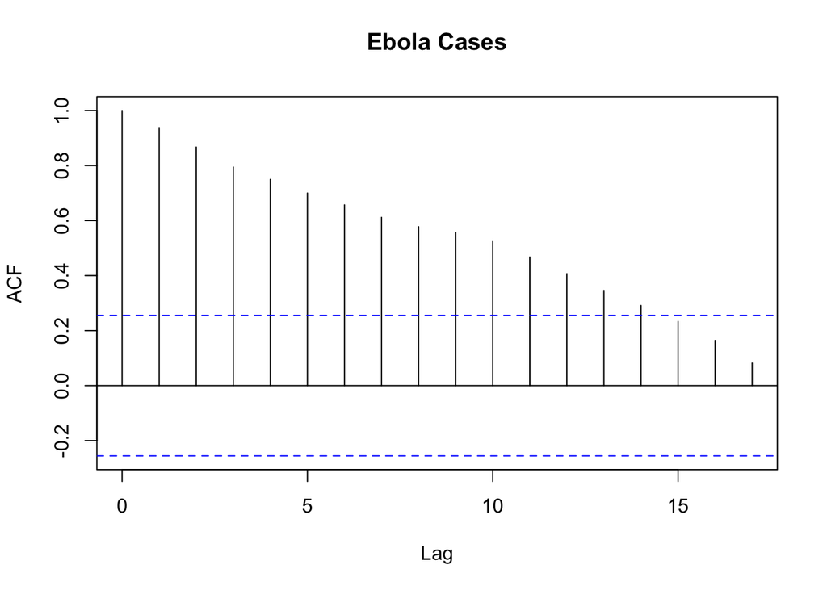

```r
acf(tp, main="Ebola Cases")
```

## Decomposition of Trend

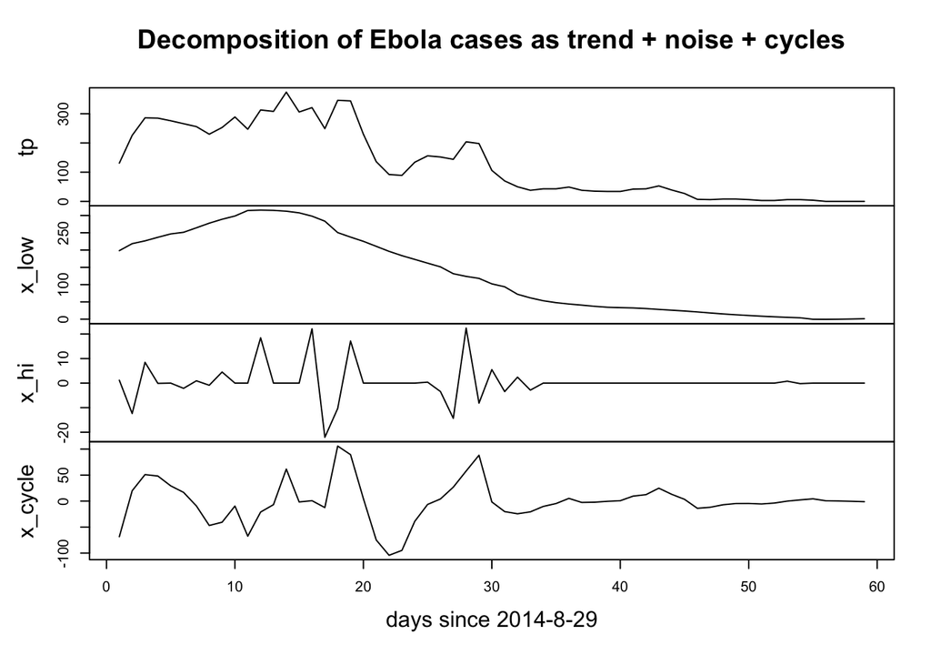

```r
x_low<-ts(loess(tp~ebola$day,span=0.5)$fitted,frequency = 1)
x_hi<-ts(tp - loess(tp~ebola$day,span=0.1)$fitted,frequency = 1)
x_cycle<- tp - x_low - x_hi
plot(ts.union(tp,x_low,x_hi,x_cycle),main='Decomposition of Ebola cases as trend + noise + cycles',xlab='days since 2014-8-29')
```

We model the data of confirmed ebola cases as a combination of three processes: Low-frequency component represents the overall trend of the data; High-frequency component represents the noise; Mid-frequency component represents the business cycle irrespective of long-term trend and short-term random noise.

## ARMA model fitting

To find the proper model, we firstly to find the proper $p$ and $q$ by AIC result.

The stationary Gaussian ARMA(p,q) model with parameter vector $\theta=(\phi_{1:p},\psi_{1:q},\mu,\sigma^2)$ given by:
$$\begin{aligned}
\phi(B)&(Y_n-\mu)=\psi(B)\epsilon_n \\
\phi(B)&=1-\phi_1B-...-\phi_pB^p,\\
\psi(B)&=1+\psi_1B+...+\psi_qB^q,\\
\epsilon_n&\sim iid N(0,\sigma^2)
\end{aligned}$$

We tabulate the AIC values:

```r
aic_table<-function(data,P,Q){
  table<-matrix(NA,(P+1),(Q+1))
  for(p in 0:P){
    for(q in 0:Q){
      table[p+1,q+1] <-arima(data,order=c(p,0,q))$aic
    }
  }
  dimnames(table)<-list(paste("AR",0:P,sep=" "),paste("MA",0:Q,sep=" "))
  table
}
temp_aic<-aic_table(tp,3,5)
require(knitr)
kable(temp_aic,digits=2)
```

[output not shown]

```r
arma22<-arima(tp,order = c(2,0,2))
arma22
```

```
##
## Call:
## arima(x = tp, order = c(2, 0, 2))
##
## Coefficients:
##          ar1     ar2     ma1     ma2  intercept
##       0.1643  0.8348  0.9835  0.2306   128.0869
## s.e.  0.2088  0.2087  0.1755  0.2130  1281.9755
##
## sigma^2 estimated as 1373:  log likelihood = -300.59,  aic = 613.18
```

```r
ar_roots<-polyroot(c(1,-coef(arma22)[c("ar1","ar2")]))
ma_roots<-polyroot(c(1,-coef(arma22)[c("ma1","ma2")]))
ar_roots
```

```
## [1]  1.000488+0i -1.197290+0i
```

```r
ma_roots
```

```
## [1]  0.8480776+0i -5.1124497-0i
```

The root analysis shows that three roots are outside of the circle and only one root is inside the unit circle, so the model could be unstable. Since we donot have other choice, we stick with arima(2,0,2) as the immediate choice.